# Relatório sobre questionário dos centros e profissionais

CREPEIA

Julho, 2017

# Considerações gerais sobre o informe

Baseado nos dados do presente relatório e de informações coletadas em outras fases do projeto geral, tais como revisão sistemática, consultas de material bibliográfico, identificação de boas práticas, entrevistas e visitas a alguns centros, apresentamos alguns pontos fortes e fracos em relação às capacitações e ações sobre triagem e intervenção breve na região da América Latina. Por fim, terminamos com algumas recomendações gerais

## Pontos fortes

- Existem experiências de implementação de triagem bastante avançadas em caráter nacional e de forma sistemática em nossa região, em especial no México, Chile e Argentina que podem servir como base para os demais países.
- Há uma grande disponibilidade de material didático de boa qualidade, produzido pelos centros em idiomas espanhol e português e adaptados às realidades da região. Além disso, há uma aprovação e satisfação geral dos profissionais em relação ao material produzido.
- As capacitações disponíveis apresentam boa aceitação pelos profissionais, que avaliam que as mesmas podem contribuir para a implementação de ações de triagem e intervenção breve, tanto as presenciais quanto as não presenciais.
- Os profissionais capacitados acreditam nas ações de triagem e intervenções breves como ações efetivas para redução do consumo de álcool, tabaco e outras drogas.
- As ações de triagem e intervenções breves implementadas parecem ser coerentes e contextualizadas à realidade e necessidades dos países latino-americanos.
- Em geral, as capacitações apresentam um caráter prático e aplicado e utilizam de diversos recursos didáticos e pedagógicos, o que facilita a tradução do conhecimento adquirido para a realidade dos profissionais e serviços.
- O setor de atenção primária é o maior foco das capacitações e implementações realizadas.
- As evidências, apesar de ainda incipientes, em geral apontam para resultados positivos tanto em termos de efetividade quanto de implementação.

## Pontos fracos

- Há uma concentração de profissionais capacitados, centros e implementação em poucos países.
- As evidências sobre triagem e intervenção breve ainda se concentram na Brasil e México.
- As evidências sobre triagem e intervenção breve ainda são incipientes quanto à sua efetividade em nossa região.
- Há a necessidade de ampliação de formação, implementação e avaliação de triagem e intervenções breves para outras populações e contextos, para além da atenção primária à saúde.
- Observou-se uma grande variação conceitual sobre que é intervenção breve, gerando uma percepção de “caixa preta”, o que dificulta a avaliação da efetividade da mesma.
- De uma forma geral, as ações de intervenção breve não foram incorporadas nos sistemas de saúde ou como estratégia oficial dos países.

## Recomendações

- Maior divulgação e articulação interinstitucional para a capacitação de profissionais e gestores, em especial em países onde existe poucas experiências de implementação, com foco na educação distância já disponíveis, pois apresentam qualidade, são contextualizados, teriam menor custo pois já estão disponíveis e tem potencial de grande abrangência regional.
- Parcerias bi ou multilaterais de capacitação e implementação de ações de triagem e intervenção breve entre países da América Latina, em especial entre países com maior experiência e os que ainda estão em fase inicial.
- Alinhamento teórico/conceitual da intervenção breve, baseado na literatura da área e das necessidades dos países.
- Trabalho de sensibilização junto às autoridades nacionais e regionais para a importância da incorporação e implementação de ações de intervenção breve nos sistemas de saúde ou outros setores.
- Maior ênfase nas avaliações e seguimentos dos profissionais após realizarem a capacitação (ênfase na implementação e aplicação dos conhecimentos adquiridos), em especial nos cursos à distância.
- Promover mais pesquisas para a produção de mais evidências sobre a efetividade da intervenção breve em diferentes contextos e populações, com ênfase principalmente na efetividade e na avaliação da implementação (processo).

# Sumário Executivo

## Resultados principais

### Centros de formação

1. México (48%) e Brasil (30,4%) foram os países com maior frequência de centros de formação;
2. As capacitações presenciais são as mais frequentes (91,2%);
3. Psicólogos (72,4%) e Assistentes Sociais (71,1%) foram as categorias profissionais mais capacitadas;
4. O instrumentos de triagem mais apresentados nas capacitações foram o AUDIT (85,7%) e ASSIST (75%).

### Profissionais de saúde

1. 90,7% dos profissionais passaram por algum tipo de avaliação de conteúdo para finalizar o treinamento;
2. O setor de saúde foi o mais frequente (76,8%) em relação ao setor de trabalho dos profissionais dos profissionais capacitados, principalmente da atenção primária à saúde (60,3%);
3. Principal população alvo das intervenções realizadas pelos profissionais são usuários de serviços de atenção primária à saúde;
4. A maioria (92,7%) acredita que a capacitação ajudou na prática e acredita que a triagem e intervenção breve contribui para a redução do consumo de álcool e outras drogas (92,5%);
5. A maioria dos profissionais (82%) utiliza instrumentos de triagem para a avaliação do consumo de álcool e outras drogas, sendo o ASSIST (89,9%) o mais utilizado;
6. Álcool (98,1%), Tabaco (91,9%) e Maconha (89%) são as substâncias abordadas com maior frequência pelos profissionais;
7. Fatores principais atribuídos como facilitadores para a implementação de ações de triagem e intervenção breve: capacitação permanente das equipes (67,7%) e apoio de autoridades, gestores e gerentes (44,4%);
8. Fatores principais atribuídos como obstáculos para a implementação de ações de triagem e intervenção breve: falta de tempo (sobrecarga de trabalho) (49,9%), falta de apoio de autoridades, gestores e gerentes (48,9%) e falta de rede disponível para tratamento (41,7%).

# Metodologia

## Instrumento de coleta de dados

Para assegurar a qualidade do instrumento de coleta, seu desenvolvimento foi conduzido em múltiplas etapas.

A versão de coleta do instrumento está disponível no link: https://enketo.ona.io/x/#YBfk

## Participantes

Para a excução do estudo, optou-se por realizar a estratégia de recrutamento e coleta de dados eletrônicos, em função da abrangência territorial previsto para a coleta de dados. Para tanto, foram seguidos todos os passos metodológicos previstos na literatura científica para pesquisas via internet. Para maximizar a abrangência da coleta, usamos diversas formas de recrutamento. Primeiramente, entramos em contato com especialistas de referência na área de vários países para divulgar o link com o formulário entre suas redes de contato. Em segundo momento, usamos diferentes listas de profissionais de saúde e centros de formação fornecidos por diversos centros de capacitação e instituições de referência tais como CICAD, UNODC, COPOLAD, INEBRIA Latina, OPS, SUPERA, dentre outros. Através de tal estratégia de divulgação e recrutamento conseguimos um vasto número de e-mails de centros e profissionais em toda a região. Por último, considerando o amplo número de profissionais capacitados pelos centros que responderam ao formulário, conforme apresentado a seguir, demonstram uma ampla cobertura de informações sobre as capacitações na região.

Foram monitorados todas as fases de envio, cliques e taxas de respostas. Ao todo, foram enviados 43.840 e-mails, com a quantidade de cliques total de 1109 (2% do total de e-mails enviados). Os resultados das campanhas são apresentados na tabela abaixo.

Resultados do recrutamento feito através de campanhas de e-mail marketing.

| Campanha | N de Destinatários | Taxa de Abertura | Cliques | Taxa de cliques |
| --- | --- | --- | --- | --- |
| Professionals - Assist-audit #2 - ES | 1854 | 0,23 | 131 | 0,07 |
| Professionals - Assist-audit, #1 - PT | 10 | 0,50 | 1 | 0,10 |
| Professionals - Assist-audit, #1 - ES | 953 | 0,45 | 146 | 0,16 |
| Centers TreatNet #1 - PT | 16 | 0,14 | 1 | 0,07 |
| Centers TreatNet #1 - ES | 34 | 0,50 | 10 | 0,31 |
| Centers #1 - PT-br | 80 | 0,17 | 1 | 0,03 |
| Centers #1 - ES | 894 | 0,36 | 76 | 0,10 |
| SUPERA | 39999 | 0,08 | 743 | 0,02 |
| Total | 43840 | 0,10 | 1109 | 0,02 |

A coleta de dados aconteceu entre 2017-01-19 e 2017-05-26. Ao todo, responderam ao questionário 1486 participantes. Destes, 102 responderam as questões ligadas a caracterização dos centros de pesquisa e 839 como profissionais de saúde que realizaram algum treinamento em intervenções breves. Abaixo segue a relação de respostas dentre aqueles que responderam.

Frequência de respostas dos questionários por tipo.

|  | N | % |
| --- | --- | --- |
| Profissionais | 839 | 56,5 |
| Nenhum | 545 | 36,7 |
| Centros | 102 | 6,9 |

## Análise dos dados

O primeiro passo da etapa de análise de dados foi a inspeção dos registros. Os registros de teste foram removidos, isto é, todos anteriores à 27 de janeiro de 2017, data da primeira divulgação da pesquisa. Após a retirada dos registros, conduzimos estatísticas descritivas usando a linguagem de programação R. Com o intuito de oferecer transparência e garantir a replicabilidade da pesquisa, todos os procedimentos de análises foram disponibilizados neste relatório. Os pacotes necessários para replicar se encontram no apêndice deste relatório.

## Resultados

A coleta de dados foi organizado em nosso formulário eletrônico em dois níveis. O primeiro se refere às informações gerais de organização, caracterização e avaliação dos centros de capacitação. Os respondentes desse questionário foram coordenadores dos centros ou de programas de capacitação ou alguém da equipe designado pelos coordenadores. Um segundo nível de nossa pesquisa foi voltada para profissionais que foram capacitados no tema. Para facilitar a interpretação e leitura, os dados do relatório foram divididos entre as respostas dos centros e dos profissionais.

# Centros de Capacitação em Intervenções Breves

Os dados apresentados nesta seção são agregados. Caso o leitor tenha interesse em conhecer as características dos centros individuais, recomendamos a leitura do outro produto desta consultoria “Censo de Los Programas de Detección Temprana e Intervención Breve, Desarrolados en la Región de las Américas a partir del 2005.”

O censo está disponível neste link

## Características dos centros

Frequência de participação por país

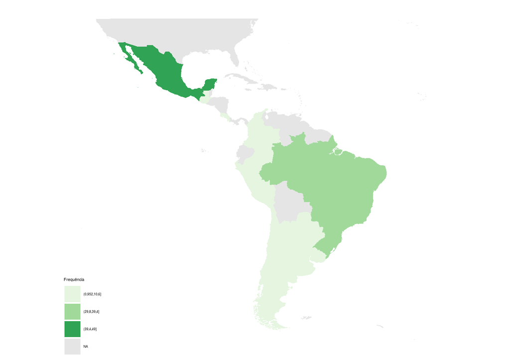

Distribuição de resposta dos centros de formação por país

| País | N | % |
| --- | --- | --- |
| Mexico | 49 | 48,0 |
| Brazil | 31 | 30,4 |
| Colombia | 9 | 8,8 |
| Chile | 4 | 3,9 |
| Argentina | 2 | 2,0 |
| Costa Rica | 2 | 2,0 |
| Guatemala | 2 | 2,0 |
| Paraguay | 1 | 1,0 |
| Peru | 1 | 1,0 |
| Uruguay | 1 | 1,0 |

A maioria dos centros (75%) estava ativo no momento da pesquisa, ou seja, ofereciam algum tipo de capacitação atual. A principal forma de capacitação oferecida é presencial (91,2%). Há uma importante variação da carga horária dos cursos com mediana de 17 horas, com um mínimo de 1 horas e máximo de 1600 horas (Tabela 4).

Características das capacitações oferecidas pelos centros

|  |  | N | % |
| --- | --- | --- | --- |
| Oferecida atualmente | Sim | 76 | 74,5 |
|  | Não | 26 | 25,5 |
| Módulo destinado a IB | Sim | 76 | 74,5 |
|  | Não | 26 | 25,5 |
| Modalidade | Presencial | 93 | 91,2 |
|  | À distância | 14 | 13,7 |
|  | Semipresencial | 6 | 5,9 |

Em relação à origem, os centros se caracterizam principalmente por serem públicos (78,9%) em detrimento às organizações não-governamentais (13,2%) e ao setor privado (7,9%).

Origem/tipo do Centro de Capacitação

|  | N | % |
| --- | --- | --- |
| Público | 60 | 78,9 |
| Organizações não governamentais (ONG) | 10 | 13,2 |
| Privado | 6 | 7,9 |

Na Tabela 5, apresentamos a porcentagem do público alvo capacitado em termos de categoria profissional. A maior frequência de profissionais capacitados foi de psicólogos (72,4%), seguidos de assistentes sociais (71,1%) e enfermeiros (56,6%). É importante ressaltar que a soma das porcentagens é maior que 100%, pois cada centro capacitou diferentes categorias profissionais.

Profissionais capacitados por categoria

|  | Sí (%) |
| --- | --- |
| Psicologia | 72,4 |
| Assistente Social | 71,1 |
| Enfermagem | 56,6 |
| Agente/Líder/Educador comunitário da saúde | 52,6 |
| Medicina | 50,0 |
| Docência | 47,4 |
| Auxiliar/ técnico de enfermagem | 43,4 |
| Estudante | 42,1 |
| Outro | 35,5 |
| Polícia | 28,9 |
| Direito | 22,4 |
| Nutrição | 21,1 |
| Fisioterapia | 11,8 |

## Recursos

A grande maioria dos centros (73,7%) incluiu a utilização de instrumentos de triagem no conteúdo das capacitações, sendo o AUDIT (85,7%) e ASSIST (75,0%) os mais utilizados (Tabela 7).

Inclusão de Instrumentos de Triagem na Capacitação? Qual (is)?

|  |  | N | % |
| --- | --- | --- | --- |
| Uso de instrumentos | Sí | 56 | 73,7 |
|  | No | 20 | 26,3 |
| Instrumentos | AUDIT | 48 | 85,7 |
|  | ASSIST | 42 | 75,0 |
|  | FAGERSTROM | 33 | 58,9 |
|  | CAGE | 18 | 32,1 |
|  | DUSI | 5 | 8,9 |
|  | Outros | 41 | 26,8 |

Os recursos pedagógicos mais frequentemente utilizados foram vídeos (78,9%) e livros, folhetos informativos (73,7%) e cartilhas (42,1%) (Tabela 8).

Recursos pedagógicos utilizados nas capacitações

|  | Sim (%) |
| --- | --- |
| Vídeos | 78,9 |
| Livros ou folhetos informativos | 73,7 |
| Cartilhas | 42,1 |
| Outros | 35,5 |
| Áudios | 31,6 |

Foram perguntados sobre algumas características ou estratégias gerais utilizadas nas capacitações. A principal característica relatada pelos informantes foi dar um caráter mais prático para o treinamentos realizados, tais como a inclusão de situações práticas para verificar o conteúdo aprendido (83,9%) e a realização de atividades práticas (73,7%). Outras estratégias ou características foi o respaldo oficial das autoridades educativas (61,8%) a atualização continuada (57,9%) e o acompanhamento dos profissionais após a capacitação (50,0%).

Características e estratégias adotadas pelos centros

|  | Sim (%) |
| --- | --- |
| Atividades práticas de avaliação | 83,9 |
| Atividades práticas durante o curso | 73,7 |
| Certificado oficialmente válido | 72,4 |
| Reconhecimento de autoridades da Educação | 61,8 |
| Formação continuada | 57,9 |
| Acompanhamento (pós-curso) das pessoas capacitadas | 50,0 |

Estratégias de divulgação das capacitações

|  | Sí (%) |
| --- | --- |
| Redes sociais | 39,5 |
| Site na internet do centro de capacitação | 25,0 |
| E-mails | 40,8 |
| Indicação de autoridades locais, nacionais ou internacionais | 75,0 |
| Outros | 19,7 |

# Profissionais

### Características Sócio-demográficas

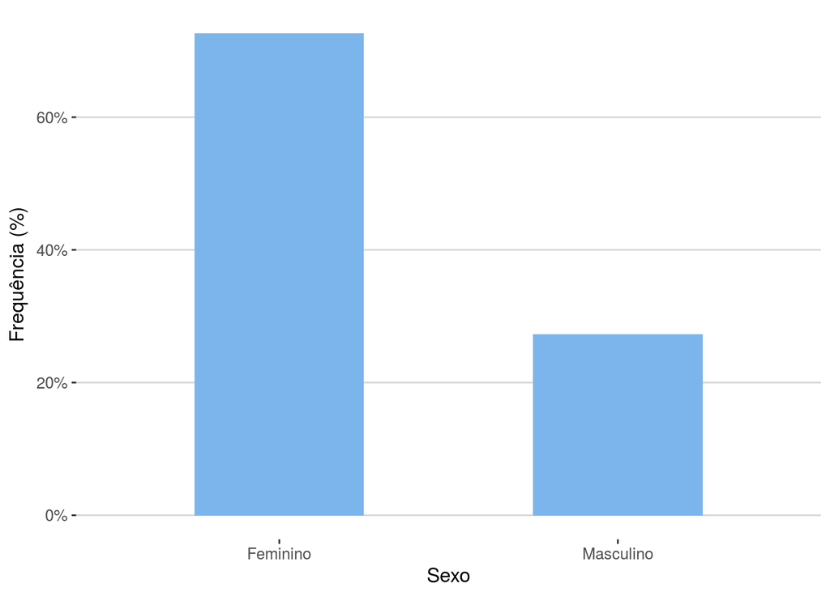

Distribuição de respostas por sexo dos participantes

Os profissionais tinham média de 38,9 (DP = 9,4).

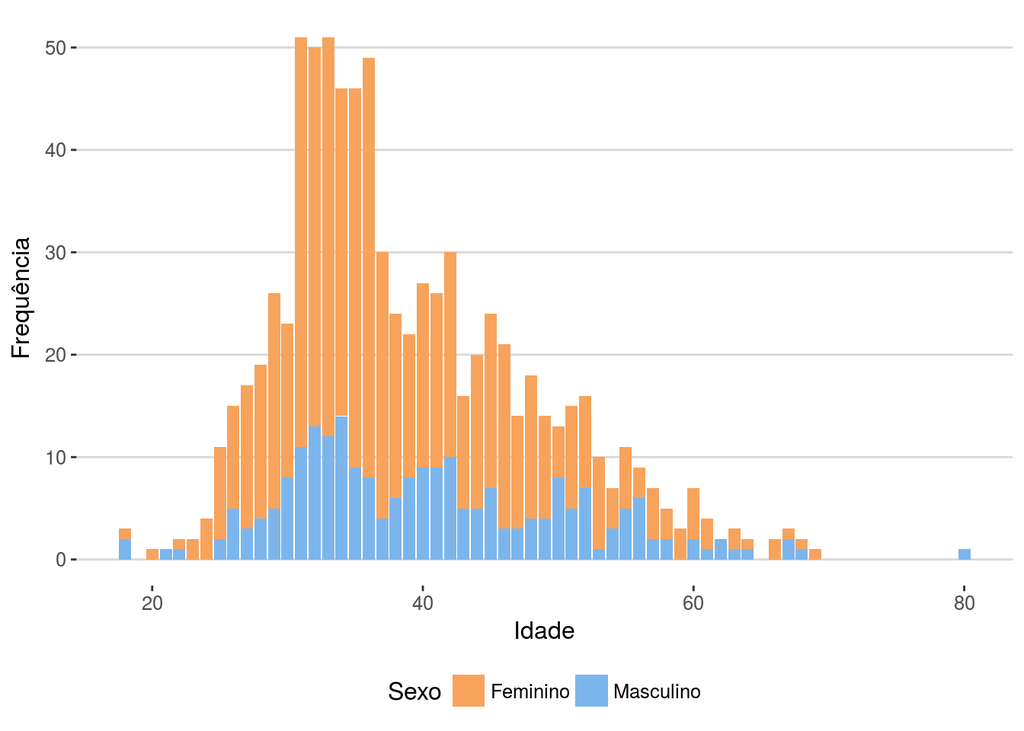

Idade por sexo dos participantes

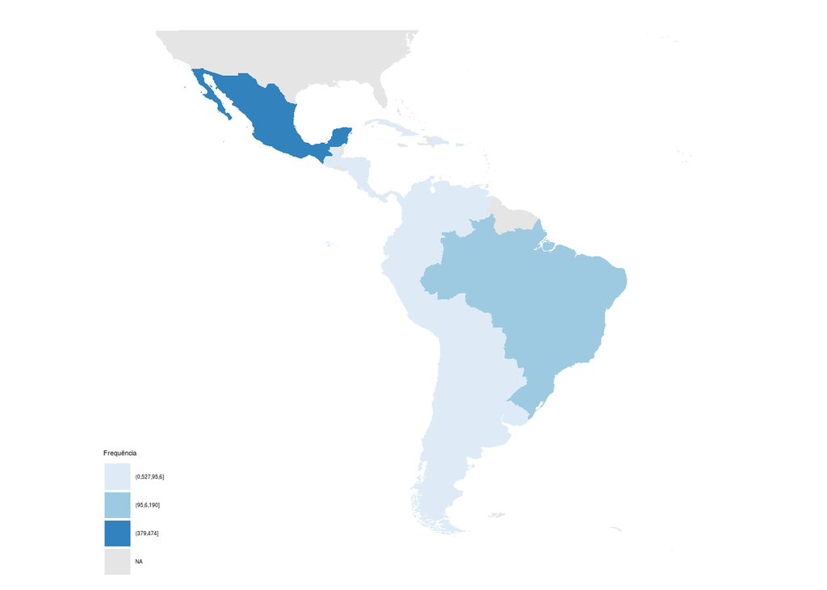

Concentração de respondentes por país

Os profissionais eram de 19 países distintos. Com resultados semelhantes à seção de caracterização dos centros, os países com o maior número de respostas foram México (57,7%), Brasil (23,0%) (Figura 4), seguido de Chile (7,3%) e Colômbia (3,6%).

Distribuição dos respondentes por país

| País | N | % |
| --- | --- | --- |
| Mexico | 474 | 57,7 |
| Brazil | 189 | 23,0 |
| Chile | 60 | 7,3 |
| Colombia | 30 | 3,6 |
| Uruguay | 13 | 1,6 |
| Ecuador | 12 | 1,5 |
| Argentina | 10 | 1,2 |
| Peru | 9 | 1,1 |
| Costa Rica | 6 | 0,7 |
| Guatemala | 4 | 0,5 |
| Puerto Rico | 3 | 0,4 |
| Bolivia | 2 | 0,2 |
| Nicaragua | 2 | 0,2 |
| Panama | 2 | 0,2 |
| Venezuela | 2 | 0,2 |
| Cuba | 1 | 0,1 |
| Honduras | 1 | 0,1 |
| Paraguay | 1 | 0,1 |
| Dominican Republic | 1 | 0,1 |

Mais da metade dos respondentes tinham com principal área de atuação a Psicologia (56,8%). Outras áreas profissionais que tiveram destaque em relação às respostas foram a Assistência Social (13,4%), a Medicina (7,5%) e a Enfermagem (6,4%) (Tabela 12).

Categoria Profissional dos participantes

| Actuación profesional | N | % |
| --- | --- | --- |
| Psicologia | 469 | 56,8 |
| Assistente Social | 111 | 13,4 |
| Medicina | 62 | 7,5 |
| Enfermagem | 53 | 6,4 |
| Outro | 43 | 5,2 |
| Docência | 36 | 4,4 |
| Agente/Líder/Educador comunitário da saúde | 30 | 3,6 |
| Estudante | 7 | 0,8 |
| Auxiliar/ técnico de enfermagem | 6 | 0,7 |
| Nutrição | 4 | 0,5 |
| Polícia | 3 | 0,4 |
| Direito | 1 | 0,1 |
| Fisioterapia | 1 | 0,1 |

Em relação à atuação profissional, a maior parte dos profissionais definiu que fazia parte de uma equipe de trabalho como profissional de assistência direta às pessoas (65,1%). As demais ocupações relatadas são de cargos administrativos tais como coordenação de equipe (20,8%) e membros da direção da instituição em que faziam parte (8,9% ) (Tabela 13).

Atuação Profissional dentro das instituições

|  | Sim (%) |
| --- | --- |
| Faço parte de uma equipe de trabalho | 65,1 |
| Coordenação de equipe | 20,8 |
| Direção da instituição | 8,9 |
| Trabalhador autônomo | 6,2 |
| Membro do quadro de funcionários | 5,4 |
| Outro | 4,2 |

### Treinamento

A maioria dos profissionais foram avaliados durante a capacitação (90,7%), receberam certificação dos centros de formação (88,1%) e receberam conteúdo específicos para a atuação na área de álcool, tabaco e outras substâncias (83,3%) (Tabela 14). O número de horas de capacitação foi bastante heterogêneo entre os profissionais. O valor mediano de horas da carga horária das capacitações foi de 50 (DIQ = 142,5). Nove entre dez profissionais disseram que sentem que a capacitação realizada os ajudaram a realizar rastreio e intervenção breve.

DIQ = Distância Interquartílica.

Frequência de profissionais que realizaram treinamento, foram avaliados e certicados

|  | Sim (%) |
| --- | --- |
| Foi avaliado durante o curso? | 90,7 |
| Recebeu certificado pela participação no curso? | 88,1 |
| Realizou algum curso de formação específica? | 83,3 |

Entre aqueles que disseram ter participado de alguma formação específica, 90,7% disseram ter realizado uma avaliação durante o curso, e 88,1% receberam algum tipo de certificação.

Qual foi a capacitação que você realizou?

|  | Sí (%) |
| --- | --- |
| Outro | 56,2 |
| ASSIST | 31,5 |
| SUPERA | 16,3 |
| Fé na Prevenção | 7,0 |
| Centro Regional de Referência sobre Drogas | 6,4 |
| Treatnet | 3,5 |

Dentre os profissionais que receberam certificação, o curso de capacitação mais realizado pelos profissionais foi o ASSIST-DIT (31,5%), seguido do SUPERA (16,3%). A categoria outros foi muito mais frequente, indicando que as categorias não foram adequadas. Dentre a categoria outros, diversos cursos foram citados como:

- AUDIT-DIT,
- Capacitação para Comunidades Terapêuticas,
- Especialidad en promoción de la Salud y Prevención del Comportamiento Adictivo (UNAM),
- Prevenção ao uso indevido de drogas para conselheiros (UFSC),
- Procedimientos Cognitivos Conductuales a través de la acción comunitaria para la prevención del comportamiento adictivo y de la supervisión de los profesionales.

### Atuação profissional

Aproximadamente três entre quatro profissionais disseram realizar intervenções breves no dia-a-dia do trabalho. A experiência mediana com intervenções breves foi de 7 anos (DIQ = 5).

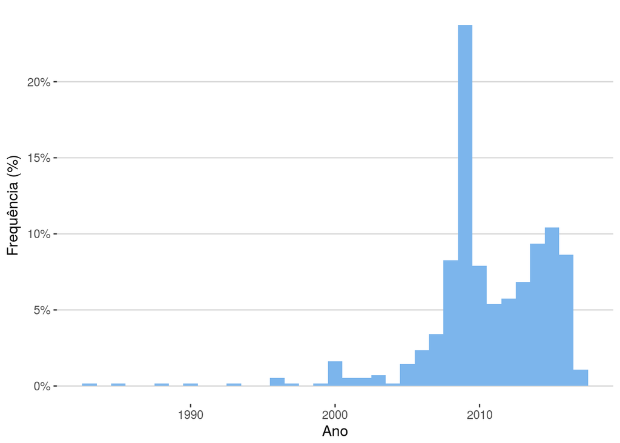

Ano de início de trabalho com IB’s

Tipo de serviço

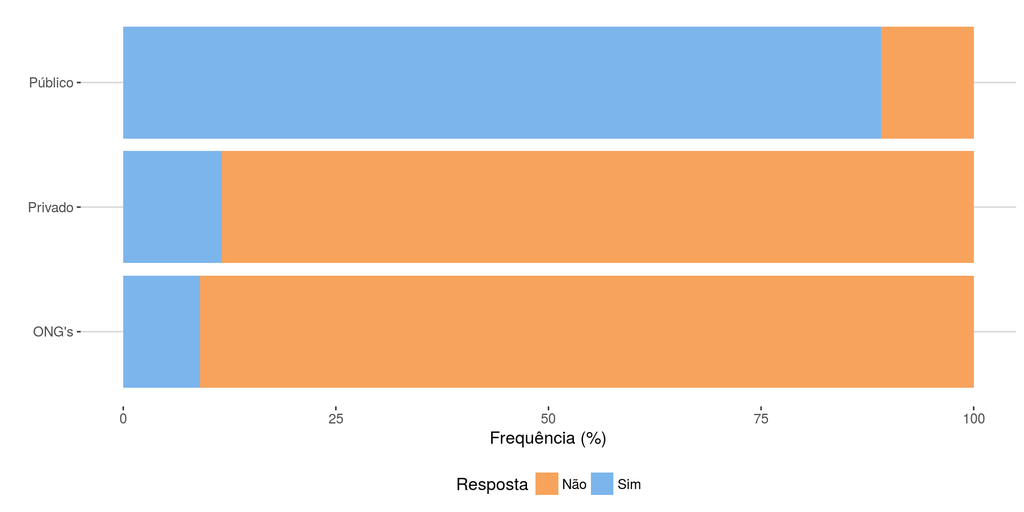

Setor de atuação dos profissionais

|  | Sí (%) |
| --- | --- |
| Saúde | 76,8 |
| Educação | 25,0 |
| Serviço Social | 11,2 |
| Outro | 7,2 |
| Justiça | 2,0 |

Dentre os profionais que atuam no setor saúde, a maioria trabalhava em serviços de atençãoo primária à saúde (60,3%), seguidos de centros de tratamento (15,8%) e ambulatórios (14,3%) (Tabela 17).

Setor da Saúde

|  | N | % |
| --- | --- | --- |
| Atenção Primária à Saúde | 324 | 60,3 |
| Centro Comunitário de Tratamento em Saúde Mental/Drogas | 85 | 15,8 |
| Ambulatorio/consulta externa | 77 | 14,3 |
| Outros | 28 | 5,2 |
| Hospitais | 23 | 4,3 |

Setor da Educação

|  | N | % |
| --- | --- | --- |
| Secundária | 123 | 70,3 |
| Superior | 23 | 13,1 |
| Primária | 15 | 8,6 |
| Outros | 14 | 8,0 |

Segundo o relato dos profissionais, a maioria das capacitações das quais eles participaram centraram na intervenção com pessoas que frequentam os serviços de atenção primária à saúde (73.1%), seguidos da intervenção com estudantes em escolas (41,8%) e usuários de serviços comunitários gerais (23,1%) (Tabela 19). Além disso, a grande maioria (92,7%) relatou que a capacitação ajudou para sua atuação sobre o tema no trabalho e 74,2% dos respondentes responderam que realizam ações de triagem e intervenção em sua rotina de trabalho

Tipo de população alvo em as intervenção eram direcionadas nas capacitações

|  | Sí (%) |
| --- | --- |
| Usuários da Atenção Primária à Saúde | 73,1 |
| Adolescentes | 41,8 |
| Usuários de serviços comunitários | 23,2 |
| Usuários em ambiente de trabalho | 17,8 |
| Usuários de outros serviços especializados (exceto álcool e outras drogas) | 10,3 |
| Outros | 8,5 |
| População de rua | 6,5 |
| População carcerária | 6,4 |

Você utiliza algum questionário de triagem (ex. AUDIT, ASSIST, CAGE, DUSI, FAGERSTROM) para perguntar sobre o consumo de drogas?

|  | N | % |
| --- | --- | --- |
| Sim | 504 | 82,0 |
| Não, mas pergunto sem usar questionário específico | 85 | 13,8 |
| Não | 26 | 4,2 |

Quais os instrumentos de triagem que são utilizados nas suas abordagens?

|  | (%) |
| --- | --- |
| ASSIST – Questionário para triagem do uso de álcool, tabaco, e outras substâncias | 89,9 |
| AUDIT – Teste de Identificação de Problemas Associados ao Uso de Álcool | 76,6 |
| FAGERSTROM – Teste de Tolerância de Fagerström | 65,5 |
| Outros | 29,2 |
| CAGE – Instrumento de detecção de problemas relacionados ao uso de álcool | 13,7 |
| DUSI – Inventário de triagem do uso de drogas para adolescentes | 3,0 |

Quais são as substâncias abordadas?

|  | (%) |
| --- | --- |
| Álcool | 98,1 |
| Tabaco | 91,9 |
| Maconha | 89,0 |
| Cocaína inalável | 69,3 |
| Inalantes | 67,4 |
| Anfetaminas | 58,4 |
| Cocaína fumável (Ex: crack) | 54,8 |
| Alucinógenos | 52,6 |
| Hipnóticos/sedativos | 45,0 |
| Opiáceos | 39,4 |
| Drogas injetáveis | 23,4 |
| Outros | 10,5 |

Uso de recursos, realização e frequência de seguimento

|  |  | N | % |
| --- | --- | --- | --- |
| Utiliza cartilhas/folhetos | Sim | 504 | 85,7 |
|  | Não | 57 | 9,7 |
|  | Outros recursos | 27 | 4,6 |
| Realiza acompanhamento? | Sim | 489 | 83,0 |
|  | Não | 100 | 17,0 |
| Frequência do acompanhamento | Semanal | 171 | 35,0 |
|  | Mensal | 268 | 54,8 |
|  | Semestral | 45 | 9,2 |
|  | Anual | 5 | 1,0 |

### Conhecimentos sobre intervenções breves

Procedimentos realizados para casos de baixo risco de consumo de álcool, tabaco e outras substâncias

|  | N | % |
| --- | --- | --- |
| Realização de abordagem educativa e entrega de material informativo (folder, cartilhas) | 398 | 67,6 |
| Referenciamento para serviços especializados | 85 | 14,4 |
| Realização de abordagem educativa sem material de apoio (folder, cartilhas) | 51 | 8,7 |
| Referenciamento para grupo de ajuda-mútua ou suporte comunitário | 49 | 8,3 |
| Não adoto nenhum procedimento | 6 | 1,0 |

Os procedimentos para usuários de risco foi semelhantes aos realizados para o nível de baixo risco de consumo, com maior frequência de intervenção educativa e entrega de material informativo (54,8%), com uma frequência maior de referenciamento para serviços especializados (28,9%) (Tabela 24).

Procedimentos realizados para casos de risco de consumo de álcool, tabaco e outras substâncias

|  | N | % |
| --- | --- | --- |
| Realização de abordagem educativa e entrega de material informativo (folder, cartilhas) | 323 | 54,8 |
| Referenciamento para serviços especializados | 170 | 28,9 |
| Referenciamento para grupo de ajuda-mútua ou suporte comunitário | 70 | 11,9 |
| Realização de abordagem educativa sem material de apoio (folder, cartilhas) | 20 | 3,4 |
| Não adoto nenhum procedimento | 6 | 1,0 |

Procedimentos realizados para usuários com diagnóstico de dependência

|  | N | % |
| --- | --- | --- |
| Referenciamento para serviços especializados | 428 | 72,7 |
| Realização de abordagem educativa sem material de apoio (folder, cartilhas) | 83 | 14,1 |
| Referenciamento para grupo de ajuda-mútua ou suporte comunitário | 62 | 10,5 |
| Realização de abordagem educativa e entrega de material informativo (folder, cartilhas) | 9 | 1,5 |
| Não adoto nenhum procedimento | 7 | 1,2 |

Com relação às práticas de triagem e intervenções breves, a maior parte dos profissionais (53,8%) afirmou que quase todos profissionais da equipe realizam tais práticas, sendo seguido por profissionais que afirmaram que poucos profissionais da equipe realizam triagem e intervenções breves (22,6%).

Percepção sobre a prática de sua equipe de triagem e intervenção breve

|  | N | % |
| --- | --- | --- |
| Quase todos os profissionais de minha equipe realizam triagem e IBs | 271 | 53,8 |
| Poucos profissionais de minha equipe realizam triagem e IBs | 114 | 22,6 |
| Muitos profissionais de minha equipe realizam triagem e IBs | 91 | 18,1 |
| Sou o único profissional de minha equipe que realiza triagem e IBs | 21 | 4,2 |
| Não atuo com equipes de trabalho | 7 | 1,4 |

A grande maioria dos profissionais (92,5%) acredita que as ações de triagem e intervenção breve contribuem para a redução do consumo de álcool e outras drogas e a maioria se baseia nessa percepção com a avaliação cotidiana de seu trabalho (64,5%).

Percepção de efetividade da IB e se profissional avalia durante a prática

|  | (%) |
| --- | --- |
| Triagem e intervenção Breve contribuem para a redução do consumo de substâncias | 92,5 |
| Avalio os resultados da implementação da triagem e Intervenção Breve no dia-a-dia | 64,5 |

Fatores atribuídos pelos profissionais como facilitadores de implementação da triagem e intervenção breve

|  | (%) |
| --- | --- |
| Programas de atualização (educação continuada) da equipe de trabalho | 67,7 |
| Suporte da autoridade responsável pelo serviço | 44,4 |
| Inclusão das atividades nas pautas e normas obrigatórias do serviço | 31,3 |
| Outros | 6,0 |

Em relação às dificuldades atribuídas para implantação das atividades de triagem e intervenção breve na rotina dos serviços, a sobrecarga de atividades (49,9%), a falta de tempo (49,9%) a falta de apoio por parte dos gestores (48,9%), a carência de uma rede especializada (41,7%) foram os obstáculos mencionados em maior frequência.

Fatores atribuídos pelos profissionais como obstáculos para a implementação de ações de triagem e intervenção breve

|  | (%) |
| --- | --- |
| Falta de tempo (sobrecarga de atividades) | 49,9 |
| Falta de apoio da gestão | 48,9 |
| Falta de serviços especializados para encaminhamento dos casos graves | 41,7 |
| Falta de treinamento | 30,9 |
| Falta de conhecimento da magnitude e das características do consumo de álcool e drogas na população | 29,7 |
| Falta de apoio da equipe | 16,8 |
| Falta de supervisão | 12,8 |
| Outros | 6,8 |

# Apêndice A - Código

Este é o código que foi usado para redigir o relatório. Você pode encontrar este material no repositório do projeto em https://github.com/henriquepgomide/cicad.

```
##   [1] "# Load packages"
##   [2] "require(mosaic)   "
##   [3] "library(knitr)"
##   [4] "library(ggplot2)"
##   [5] "library(ggthemes)"
##   [6] "library(ggmap)"
##   [7] "library(scales)"
##   [8] "library(car)"
##   [9] "library(dplyr)"
##  [10] "library(tidyr)"
##  [11] "library(tibble)"
##  [12] "library(sjPlot)"
##  [13] ""
##  [14] "# Some customization.  You can alter or delete as desired (if you know what you are doing)."
##  [15] "options(OutDec= \",\")"
```

[output cut: 535 more lines]